# Neighboring COOP stations in the Yampa and Rio Grande areas

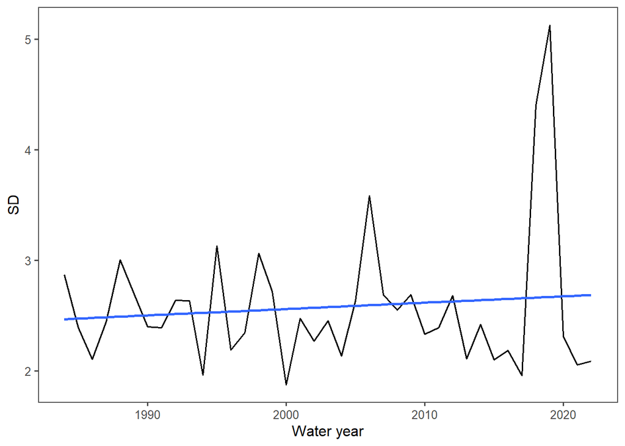

```r
ggplot(CO7656_standard_dev_all_summer, aes(x = waterYear, y = sd_2))+
  geom_line(size= 0.7) +
  theme_few() +
  geom_smooth(method = "lm", se=FALSE) +
  ylab('SD') +
  xlab('Water year')
```

**CO7656 Jun-Aug standard deviation for water years 1984-2022**

Mann-Kendall & Sen’s Slope

Summer standard deviations.

```r
CO7656_sd_mk_summer <- mk.test(CO7656_standard_dev_all_summer$sd_2)
print(CO7656_sd_mk_summer)
```

```
##
##  Mann-Kendall trend test
##
## data:  CO7656_standard_dev_all_summer$sd_2
## z = -1.3548, n = 39, p-value = 0.1755
## alternative hypothesis: true S is not equal to 0
## sample estimates:
##            S         varS          tau
## -113.0000000 6833.6666667   -0.1524966
```

```r
CO7656_sd_sens_summer <- sens.slope(CO7656_standard_dev_all_summer$sd_2)
print(CO7656_sd_sens_summer)
```

```
##
##  Sen's slope
##
## data:  CO7656_standard_dev_all_summer$sd_2
## z = -1.3548, n = 39, p-value = 0.1755
## alternative hypothesis: true z is not equal to 0
## 95 percent confidence interval:
##  -0.017626864  0.004829158
## sample estimates:
##  Sen's slope
## -0.007146811
```

Winter temperature standard deviation

```r
CO7656_standard_dev_all_winter <- CO7656_standard_dev %>%
  filter(waterDay >= 32 & waterDay <= 182) %>% # this might be better off as daymonth rather than day of water year due to leap year
  group_by(waterYear) %>%
  mutate(nmbr = n())

# Nope. This did some weird stuff with twice the observations.
# CO7656_standard_dev_all_winter <- CO7656_standard_dev %>%
#   filter(daymonth >= "01-11" & daymonth <= "31-03") %>%
#   group_by(waterYear) %>%
#   mutate(nmbr = n())


CO7656_standard_dev_all_winter <- CO7656_standard_dev_all_winter %>%
  group_by(waterYear) %>%
  mutate(resid_mean = mean(residual)) %>%
  mutate(sd_1 = residual-resid_mean) %>%
  mutate(sd_2 = (((sum((sd_1)^2))/((nmbr-1))))^(0.5)) %>%
  distinct(sd_2, .keep_all = TRUE) %>%
   select(waterYear, sd_2)

CO7656_standard_dev_all_winter %>%
  kable(.,'html') %>%
  kable_styling() %>%
  scroll_box(width='250px',height='500px')
```

| waterYear | sd_2 |
| --- | --- |
| 1984 | 5.825255 |
| 1985 | 5.791930 |
| 1986 | 5.050040 |
| 1987 | 4.148185 |
| 1988 | 5.340055 |
| 1989 | 6.451878 |
| 1990 | 5.408032 |
| 1991 | 5.549401 |
| 1992 | 4.346191 |
| 1993 | 4.615703 |
| 1994 | 4.994627 |
| 1995 | 5.023145 |
| 1996 | 5.152052 |
| 1997 | 5.188795 |
| 1998 | 5.001190 |
| 1999 | 4.579430 |
| 2000 | 5.007575 |
| 2001 | 4.586201 |
| 2002 | 5.744089 |
| 2003 | 4.401514 |
| 2004 | 5.709564 |
| 2005 | 4.848385 |
| 2006 | 4.140175 |
| 2007 | 5.949719 |
| 2008 | 6.572679 |
| 2009 | 5.229943 |
| 2010 | 5.141441 |
| 2011 | 6.174123 |
| 2012 | 4.602861 |
| 2013 | 6.207070 |
| 2014 | 4.883980 |
| 2015 | 5.137885 |
| 2016 | 5.442594 |
| 2017 | 6.400228 |
| 2018 | 5.314075 |
| 2019 | 5.040701 |
| 2020 | 5.359974 |
| 2021 | 4.899933 |
| 2022 | 5.611303 |

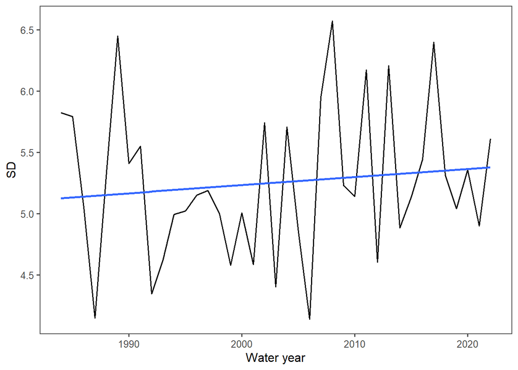

```r
ggplot(CO7656_standard_dev_all_winter, aes(x = waterYear, y = sd_2))+#, color = waterYear)) +
  geom_line(size= 0.7) +
  #geom_line(aes) +
  theme_few() +
  geom_smooth(method = "lm", se=FALSE) +
  ylab('SD') +
  xlab('Water year')
```

**CO7656 Nov-Mar standard deviation for water years 1984-2022**

Mann-Kendall & Sen’s Slope

Winter standard deviations.

```r
CO7656_sd_mk_winter <- mk.test(CO7656_standard_dev_all_winter$sd_2)
print(CO7656_sd_mk_winter)
```

```
##
##  Mann-Kendall trend test
##
## data:  CO7656_standard_dev_all_winter$sd_2
## z = 0.58065, n = 39, p-value = 0.5615
## alternative hypothesis: true S is not equal to 0
## sample estimates:
##            S         varS          tau
## 4.900000e+01 6.833667e+03 6.612686e-02
```

```r
CO7656_sd_sens_winter <- sens.slope(CO7656_standard_dev_all_winter$sd_2)
print(CO7656_sd_sens_winter)
```

```
##
##  Sen's slope
##
## data:  CO7656_standard_dev_all_winter$sd_2
## z = 0.58065, n = 39, p-value = 0.5615
## alternative hypothesis: true z is not equal to 0
## 95 percent confidence interval:
##  -0.01262523  0.02718868
## sample estimates:
## Sen's slope
## 0.005991615
```

## VALLECITO DAM *CO8582*

Detrending Data

```r
#average water year temperature

CO8582_yearly_wy_aver <- COOP_stations_clean %>%
  filter(station == "CO8582") %>%
  group_by(waterYear) %>%
  filter(waterYear >= 1984) %>%
  mutate(aver_ann_temp = mean(avg_T_c))

CO8582_temp_xts <- xts(CO8582_yearly_wy_aver$avg_T_c, order.by = CO8582_yearly_wy_aver$Date)

dygraph(CO8582_temp_xts) %>%
  dyAxis("y", label = "Daily temperature (°C)")
```

[interactive chart not shown]

```r
#Average temperature by day for all water years:

CO8582_daily_wy_aver <- CO8582_yearly_wy_aver %>%
  group_by(daymonth) %>%
  mutate(aver_day_temp = mean(aver_ann_temp))

#average mean temperature by day for the period of record:

CO8582_daily_wy_aver <- CO8582_daily_wy_aver %>%
  group_by(daymonth) %>%
  mutate(all_ave_temp = mean(CO8582_daily_wy_aver$aver_day_temp))

#str(CO8582_daily_wy_aver)
```

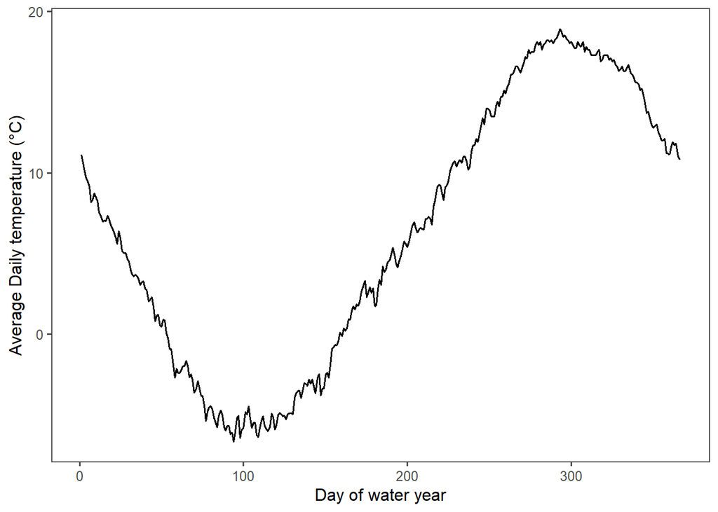

```r
# try to show all years as means.
CO8582_daily_wy_aver2 <- CO8582_daily_wy_aver %>%
  #filter(waterYear == "1987" | waterYear == "2021") %>%
  group_by(waterDay) %>%
  mutate(date_temp = mean(avg_T_c))

CO8582_daily_wy_aver2$date_temp <- signif(CO8582_daily_wy_aver2$date_temp,3) #reduce the sig figs

ggplot(CO8582_daily_wy_aver2, aes(x = waterDay, y = date_temp))+#, color = waterYear)) +
  geom_line(size= 0.7) +
  #geom_line(aes) +
  theme_few() +
  #geom_smooth(method = "lm", se=FALSE) +
  ylab('Average Daily temperature (°C)') +
  xlab('Day of water year')
```

Standard deviation- Determining residuals

```r
CO8582_standard_dev <- CO8582_daily_wy_aver %>%
  group_by(waterYear) %>%
  mutate(residual = (all_ave_temp-aver_ann_temp)+avg_T_c-aver_day_temp) %>%
  mutate(deviation = abs(residual-lag(residual)))

mean(CO8582_standard_dev$residual)
```

```
## [1] -6.23937e-16
```

*The mean of the residuals is close enough to zero*

Calculating standard deviation for the timeseries

```r
CO8582_standard_dev_all <- CO8582_standard_dev %>%
  group_by(waterYear) %>%
  mutate(nmbr = n())

CO8582_standard_dev_all <- CO8582_standard_dev_all %>%
  group_by(waterYear) %>%
  mutate(resid_mean = mean(residual)) %>%
  mutate(sd_1 = residual-resid_mean) %>%
  mutate(sd_2 = (((sum((sd_1)^2))/((nmbr-1))))^(0.5)) %>%
  distinct(sd_2, .keep_all = TRUE) %>%
   select(waterYear, sd_2)

CO8582_standard_dev_all %>%
  kable(.,'html') %>%
  kable_styling() %>%
  scroll_box(width='250px',height='500px')
```

| waterYear | sd_2 |
| --- | --- |
| 1984 | 9.383586 |
| 1985 | 8.747479 |
| 1986 | 7.843649 |
| 1987 | 8.290687 |
| 1988 | 9.157787 |
| 1989 | 9.113597 |
| 1990 | 8.535844 |
| 1991 | 9.094549 |
| 1992 | 8.416527 |
| 1993 | 8.647521 |
| 1994 | 9.052431 |
| 1995 | 8.578530 |
| 1996 | 8.579043 |
| 1997 | 9.107490 |
| 1998 | 9.383756 |
| 1999 | 7.505741 |
| 2000 | 8.676708 |
| 2001 | 9.337435 |
| 2002 | 9.637440 |
| 2003 | 8.889594 |
| 2004 | 9.112936 |
| 2005 | 8.538574 |
| 2006 | 8.461740 |
| 2007 | 9.192161 |
| 2008 | 9.868298 |
| 2009 | 8.660182 |
| 2010 | 9.849250 |
| 2011 | 9.352170 |
| 2012 | 9.066766 |
| 2013 | 9.972813 |
| 2014 | 8.277648 |
| 2015 | 7.734352 |
| 2016 | 8.860104 |
| 2017 | 8.171528 |
| 2018 | 8.242078 |
| 2019 | 9.613219 |
| 2020 | 9.334744 |
| 2021 | 9.524267 |
| 2022 | 8.975630 |

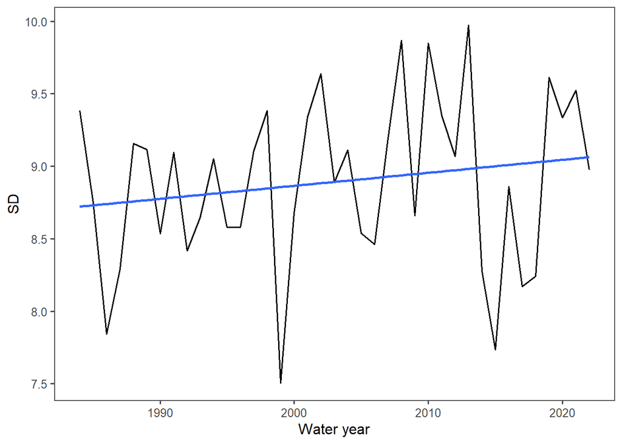

```r
ggplot(CO8582_standard_dev_all, aes(x = waterYear, y = sd_2))+
  geom_line(size= 0.7) +
  theme_few() +
  geom_smooth(method = "lm", se=FALSE) +
  ylab('SD') +
  xlab('Water year')
```

```r
CO8582_sd_mk <- mk.test(CO8582_standard_dev_all$sd_2)
print(CO8582_sd_mk)
```

```
##
##  Mann-Kendall trend test
##
## data:  CO8582_standard_dev_all$sd_2
## z = 0.94356, n = 39, p-value = 0.3454
## alternative hypothesis: true S is not equal to 0
## sample estimates:
##            S         varS          tau
##   79.0000000 6833.6666667    0.1066127
```

```r
CO8582_sd_sens <- sens.slope(CO8582_standard_dev_all$sd_2)
print(CO8582_sd_sens)
```

```
##
##  Sen's slope
##
## data:  CO8582_standard_dev_all$sd_2
## z = 0.94356, n = 39, p-value = 0.3454
## alternative hypothesis: true z is not equal to 0
## 95 percent confidence interval:
##  -0.009377773  0.030402032
## sample estimates:
## Sen's slope
##  0.01084421
```

Summer temperature standard deviation

```r
CO8582_standard_dev_all_summer <- CO8582_standard_dev %>%
  filter(waterDay >= 244 & waterDay <= 335) %>% # this might be better off as daymonth rather than day of water year due to leap year
  group_by(waterYear) %>%
  mutate(nmbr = n())

CO8582_standard_dev_all_summer <- CO8582_standard_dev_all_summer %>%
  group_by(waterYear) %>%
  mutate(resid_mean = mean(residual)) %>%
  mutate(sd_1 = residual-resid_mean) %>%
  mutate(sd_2 = (((sum((sd_1)^2))/((nmbr-1))))^(0.5)) %>%
  distinct(sd_2, .keep_all = TRUE) %>%
   select(waterYear, sd_2)

CO8582_standard_dev_all_summer %>%
  kable(.,'html') %>%
  kable_styling() %>%
  scroll_box(width='250px',height='500px')
```

| waterYear | sd_2 |
| --- | --- |
| 1984 | 2.813935 |
| 1985 | 2.637505 |
| 1986 | 2.404488 |
| 1987 | 2.448139 |
| 1988 | 2.532795 |
| 1989 | 2.833055 |
| 1990 | 2.690463 |
| 1991 | 2.554909 |
| 1992 | 2.738031 |
| 1993 | 2.938426 |
| 1994 | 1.921098 |
| 1995 | 3.603464 |
| 1996 | 1.873828 |
| 1997 | 2.502794 |
| 1998 | 3.417954 |
| 1999 | 2.629655 |
| 2000 | 1.999305 |
| 2001 | 2.422970 |
| 2002 | 2.118775 |
| 2003 | 2.967155 |
| 2004 | 2.537188 |
| 2005 | 3.173025 |
| 2006 | 2.199192 |
| 2007 | 2.735728 |
| 2008 | 2.789759 |
| 2009 | 3.198484 |
| 2010 | 2.485891 |
| 2011 | 2.499998 |
| 2012 | 1.885593 |
| 2013 | 2.159771 |
| 2014 | 2.354197 |
| 2015 | 2.552712 |
| 2016 | 2.537342 |
| 2017 | 2.201989 |
| 2018 | 2.089558 |
| 2019 | 2.877991 |
| 2020 | 2.368652 |
| 2021 | 2.142237 |
| 2022 | 2.401416 |

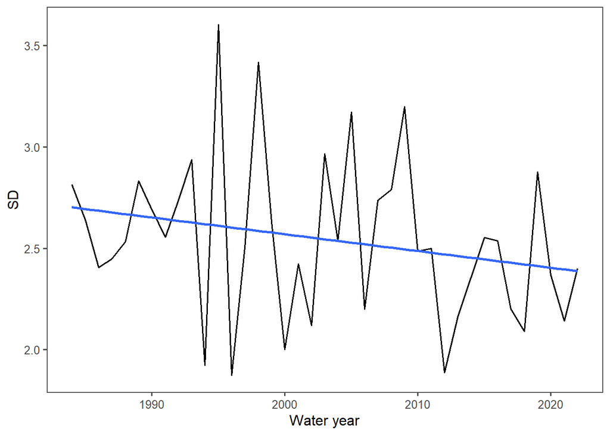

```r
ggplot(CO8582_standard_dev_all_summer, aes(x = waterYear, y = sd_2))+
  geom_line(size= 0.7) +
  theme_few() +
  geom_smooth(method = "lm", se=FALSE) +
  ylab('SD') +
  xlab('Water year')
```

**CO8582 Jun-Aug standard deviation for water years 1984-2022**

Mann-Kendall & Sen’s Slope

Summer standard deviations.

```r
CO8582_sd_mk_summer <- mk.test(CO8582_standard_dev_all_summer$sd_2)
print(CO8582_sd_mk_summer)
```

```
##
##  Mann-Kendall trend test
##
## data:  CO8582_standard_dev_all_summer$sd_2
## z = -1.5, n = 39, p-value = 0.1336
## alternative hypothesis: true S is not equal to 0
## sample estimates:
##           S        varS         tau
## -125.000000 6833.666667   -0.168691
```

```r
CO8582_sd_sens_summer <- sens.slope(CO8582_standard_dev_all_summer$sd_2)
print(CO8582_sd_sens_summer)
```

```
##
##  Sen's slope
##
## data:  CO8582_standard_dev_all_summer$sd_2
## z = -1.5, n = 39, p-value = 0.1336
## alternative hypothesis: true z is not equal to 0
## 95 percent confidence interval:
##  -0.018363877  0.003232946
## sample estimates:
##  Sen's slope
## -0.008549483
```

Winter temperature standard deviation

```r
CO8582_standard_dev_all_winter <- CO8582_standard_dev %>%
  filter(waterDay >= 32 & waterDay <= 182) %>% # this might be better off as daymonth rather than day of water year due to leap year
  group_by(waterYear) %>%
  mutate(nmbr = n())

# Nope. This did some weird stuff with twice the observations.
# CO8582_standard_dev_all_winter <- CO8582_standard_dev %>%
#   filter(daymonth >= "01-11" & daymonth <= "31-03") %>%
#   group_by(waterYear) %>%
#   mutate(nmbr = n())


CO8582_standard_dev_all_winter <- CO8582_standard_dev_all_winter %>%
  group_by(waterYear) %>%
  mutate(resid_mean = mean(residual)) %>%
  mutate(sd_1 = residual-resid_mean) %>%
  mutate(sd_2 = (((sum((sd_1)^2))/((nmbr-1))))^(0.5)) %>%
  distinct(sd_2, .keep_all = TRUE) %>%
   select(waterYear, sd_2)

CO8582_standard_dev_all_winter %>%
  kable(.,'html') %>%
  kable_styling() %>%
  scroll_box(width='250px',height='500px')
```

| waterYear | sd_2 |
| --- | --- |
| 1984 | 5.310241 |
| 1985 | 5.045484 |
| 1986 | 4.862671 |
| 1987 | 4.267177 |
| 1988 | 5.301464 |
| 1989 | 6.017133 |
| 1990 | 5.570090 |
| 1991 | 5.607337 |
| 1992 | 4.574863 |
| 1993 | 4.345881 |
| 1994 | 4.847218 |
| 1995 | 4.719710 |
| 1996 | 5.023067 |
| 1997 | 5.487041 |
| 1998 | 4.711243 |
| 1999 | 3.973766 |
| 2000 | 4.915390 |
| 2001 | 4.399419 |
| 2002 | 5.274510 |
| 2003 | 4.056802 |
| 2004 | 6.212342 |
| 2005 | 4.020457 |
| 2006 | 4.485868 |
| 2007 | 5.860868 |
| 2008 | 6.447097 |
| 2009 | 5.180071 |
| 2010 | 5.170040 |
| 2011 | 5.570027 |
| 2012 | 4.282039 |
| 2013 | 6.514920 |
| 2014 | 4.645525 |
| 2015 | 4.899033 |
| 2016 | 5.148721 |
| 2017 | 5.486057 |
| 2018 | 4.427436 |
| 2019 | 4.891143 |
| 2020 | 4.681322 |
| 2021 | 5.170427 |
| 2022 | 5.084264 |

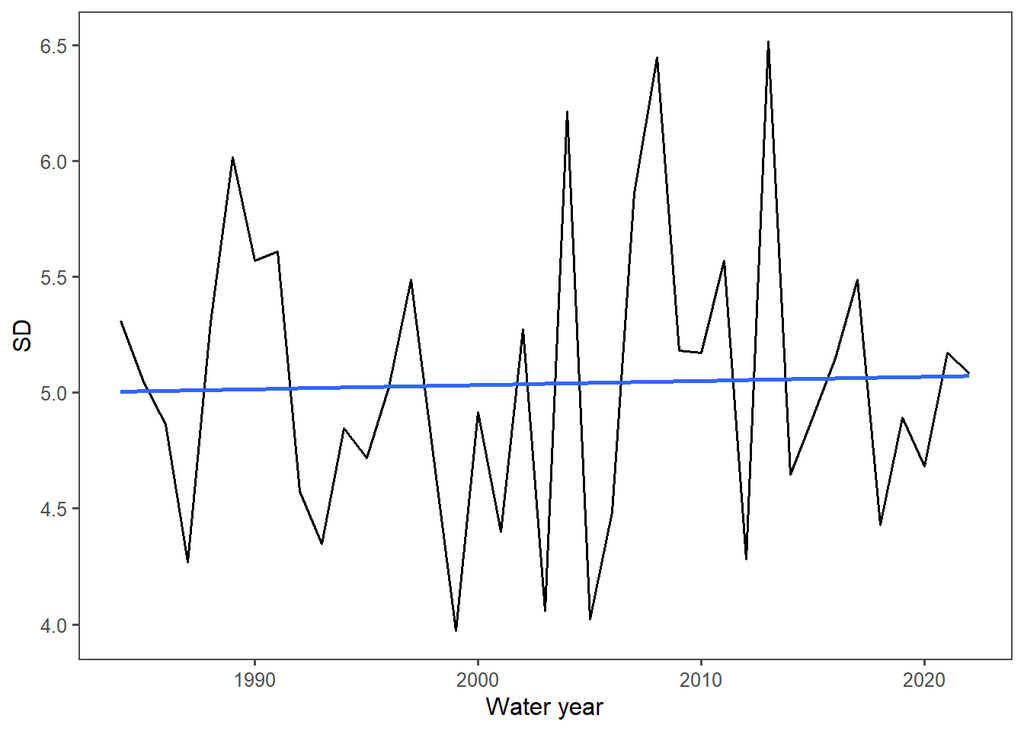

```r
ggplot(CO8582_standard_dev_all_winter, aes(x = waterYear, y = sd_2))+#, color = waterYear)) +
  geom_line(size= 0.7) +
  #geom_line(aes) +
  theme_few() +
  geom_smooth(method = "lm", se=FALSE) +
  ylab('SD') +
  xlab('Water year')
```

**CO8582 Nov-Mar standard deviation for water years 1984-2022**

Mann-Kendall & Sen’s Slope

Winter standard deviations.

```r
CO8582_sd_mk_winter <- mk.test(CO8582_standard_dev_all_winter$sd_2)
print(CO8582_sd_mk_winter)
```

```
##
##  Mann-Kendall trend test
##
## data:  CO8582_standard_dev_all_winter$sd_2
## z = -0.048387, n = 39, p-value = 0.9614
## alternative hypothesis: true S is not equal to 0
## sample estimates:
##             S          varS           tau
## -5.000000e+00  6.833667e+03 -6.747638e-03
```

```r
CO8582_sd_sens_winter <- sens.slope(CO8582_standard_dev_all_winter$sd_2)
print(CO8582_sd_sens_winter)
```

```
##
##  Sen's slope
##
## data:  CO8582_standard_dev_all_winter$sd_2
## z = -0.048387, n = 39, p-value = 0.9614
## alternative hypothesis: true z is not equal to 0
## 95 percent confidence interval:
##  -0.01834464  0.02017638
## sample estimates:
##   Sen's slope
## -0.0008037351
```

## DEL NORTE 2E *CO2184*

Detrending Data

```r
#average water year temperature

CO2184_yearly_wy_aver <- COOP_stations_clean %>%
  filter(station == "CO2184") %>%
  group_by(waterYear) %>%
  filter(waterYear >= 1984) %>%
  mutate(aver_ann_temp = mean(avg_T_c))
```

```r
#Average temperature by day for all water years:

CO2184_daily_wy_aver <- CO2184_yearly_wy_aver %>%
  group_by(daymonth) %>%
  mutate(aver_day_temp = mean(aver_ann_temp))

#average mean temperature by day for the period of record:

CO2184_daily_wy_aver <- CO2184_daily_wy_aver %>%
  group_by(daymonth) %>%
  mutate(all_ave_temp = mean(CO2184_daily_wy_aver$aver_day_temp))

#str(CO2184_daily_wy_aver)
```

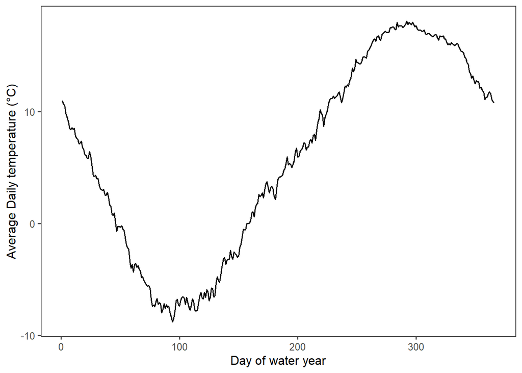

```r
# try to show all years as means.
CO2184_daily_wy_aver2 <- CO2184_daily_wy_aver %>%
  #filter(waterYear == "1987" | waterYear == "2021") %>%
  group_by(waterDay) %>%
  mutate(date_temp = mean(avg_T_c))

CO2184_daily_wy_aver2$date_temp <- signif(CO2184_daily_wy_aver2$date_temp,3) #reduce the sig figs

ggplot(CO2184_daily_wy_aver2, aes(x = waterDay, y = date_temp))+#, color = waterYear)) +
  geom_line(size= 0.7) +
  #geom_line(aes) +
  theme_few() +
  #geom_smooth(method = "lm", se=FALSE) +
  ylab('Average Daily temperature (°C)') +
  xlab('Day of water year')
```

Standard deviation- Determining residuals

```r
CO2184_standard_dev <- CO2184_daily_wy_aver %>%
  group_by(waterYear) %>%
  mutate(residual = (all_ave_temp-aver_ann_temp)+avg_T_c-aver_day_temp) %>%
  mutate(deviation = abs(residual-lag(residual)))

mean(CO2184_standard_dev$residual)
```

```
## [1] -3.33898e-17
```

*The mean of the residuals is close enough to zero*

Calculating standard deviation for the timeseries

```r
CO2184_standard_dev_all <- CO2184_standard_dev %>%
  group_by(waterYear) %>%
  mutate(nmbr = n())

CO2184_standard_dev_all <- CO2184_standard_dev_all %>%
  group_by(waterYear) %>%
  mutate(resid_mean = mean(residual)) %>%
  mutate(sd_1 = residual-resid_mean) %>%
  mutate(sd_2 = (((sum((sd_1)^2))/((nmbr-1))))^(0.5)) %>%
  distinct(sd_2, .keep_all = TRUE) %>%
   select(waterYear, sd_2)

CO2184_standard_dev_all %>%
  kable(.,'html') %>%
  kable_styling() %>%
  scroll_box(width='250px',height='500px')
```

| waterYear | sd_2 |
| --- | --- |
| 1984 | 10.851354 |
| 1985 | 9.322284 |
| 1986 | 8.117289 |
| 1987 | 8.930130 |
| 1988 | 10.122162 |
| 1989 | 9.678175 |
| 1990 | 8.420811 |
| 1991 | 9.283741 |
| 1992 | 10.283845 |
| 1993 | 9.683157 |
| 1994 | 9.228863 |
| 1995 | 7.734984 |
| 1996 | 8.180139 |
| 1997 | 8.928496 |
| 1998 | 9.265695 |
| 1999 | 7.731617 |
| 2000 | 8.352092 |
| 2001 | 9.255820 |
| 2002 | 9.754404 |
| 2003 | 8.884745 |
| 2004 | 9.145182 |
| 2005 | 8.664351 |
| 2006 | 8.681983 |
| 2007 | 10.102809 |
| 2008 | 10.762096 |
| 2009 | 8.982543 |
| 2010 | 9.892880 |
| 2011 | 9.413105 |
| 2012 | 10.074149 |
| 2013 | 11.257504 |
| 2014 | 10.017296 |
| 2015 | 8.434601 |
| 2016 | 8.996848 |
| 2017 | 8.840504 |
| 2018 | 8.044550 |
| 2019 | 9.547470 |
| 2020 | 10.455481 |
| 2021 | 9.952095 |
| 2022 | 9.426592 |

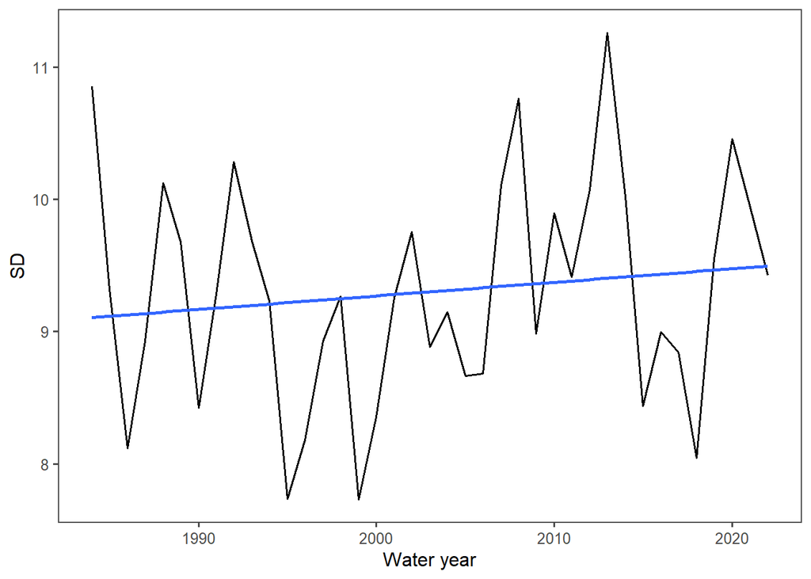

```r
#CALLING THIS something different
CO2184_all_V2 <- ggplot(CO2184_standard_dev_all, aes(x = waterYear, y = sd_2))+
  geom_line(size= 0.7) +
  theme_few() +
  geom_smooth(method = "lm", se=FALSE) +
  ylab('SD') +
  xlab('Water year')


print(CO2184_all_V2)
```

```r
CO2184_sd_mk <- mk.test(CO2184_standard_dev_all$sd_2)
print(CO2184_sd_mk)
```

```
##
##  Mann-Kendall trend test
##
## data:  CO2184_standard_dev_all$sd_2
## z = 0.72581, n = 39, p-value = 0.468
## alternative hypothesis: true S is not equal to 0
## sample estimates:
##            S         varS          tau
## 6.100000e+01 6.833667e+03 8.232119e-02
```

```r
CO2184_sd_sens <- sens.slope(CO2184_standard_dev_all$sd_2)
print(CO2184_sd_sens)
```

```
##
##  Sen's slope
##
## data:  CO2184_standard_dev_all$sd_2
## z = 0.72581, n = 39, p-value = 0.468
## alternative hypothesis: true z is not equal to 0
## 95 percent confidence interval:
##  -0.01500289  0.03885031
## sample estimates:
## Sen's slope
##  0.01041623
```

Summer temperature standard deviation

```r
CO2184_standard_dev_all_summer <- CO2184_standard_dev %>%
  filter(waterDay >= 244 & waterDay <= 335) %>% # this might be better off as daymonth rather than day of water year due to leap year
  group_by(waterYear) %>%
  mutate(nmbr = n())

CO2184_standard_dev_all_summer <- CO2184_standard_dev_all_summer %>%
  group_by(waterYear) %>%
  mutate(resid_mean = mean(residual)) %>%
  mutate(sd_1 = residual-resid_mean) %>%
  mutate(sd_2 = (((sum((sd_1)^2))/((nmbr-1))))^(0.5)) %>%
  distinct(sd_2, .keep_all = TRUE) %>%
   select(waterYear, sd_2)

CO2184_standard_dev_all_summer %>%
  kable(.,'html') %>%
  kable_styling() %>%
  scroll_box(width='250px',height='500px')
```

| waterYear | sd_2 |
| --- | --- |
| 1984 | 2.391702 |
| 1985 | 2.143789 |
| 1986 | 1.884837 |
| 1987 | 1.827067 |
| 1988 | 2.187482 |
| 1989 | 2.292524 |
| 1990 | 2.135460 |
| 1991 | 2.107556 |
| 1992 | 2.327857 |
| 1993 | 2.347764 |
| 1994 | 1.627795 |
| 1995 | 2.551853 |
| 1996 | 2.100201 |
| 1997 | 1.926402 |
| 1998 | 2.600348 |
| 1999 | 2.410172 |
| 2000 | 1.600572 |
| 2001 | 2.019630 |
| 2002 | 1.845975 |
| 2003 | 2.801925 |
| 2004 | 2.332780 |
| 2005 | 2.619140 |
| 2006 | 1.996965 |
| 2007 | 2.363320 |
| 2008 | 2.356730 |
| 2009 | 2.488327 |
| 2010 | 1.954418 |
| 2011 | 2.097681 |
| 2012 | 1.719314 |
| 2013 | 2.269814 |
| 2014 | 2.174603 |
| 2015 | 2.003585 |
| 2016 | 2.357237 |
| 2017 | 2.187614 |
| 2018 | 2.098239 |
| 2019 | 2.398375 |
| 2020 | 2.058420 |
| 2021 | 2.540783 |
| 2022 | 2.216535 |

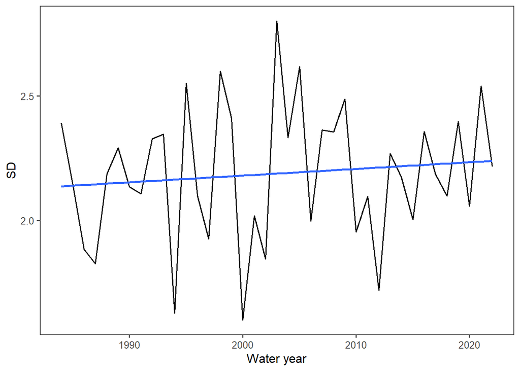

```r
ggplot(CO2184_standard_dev_all_summer, aes(x = waterYear, y = sd_2))+
  geom_line(size= 0.7) +
  theme_few() +
  geom_smooth(method = "lm", se=FALSE) +
  ylab('SD') +
  xlab('Water year')
```

**CO2184 Jun-Aug standard deviation for water years 1984-2022**

Mann-Kendall & Sen’s Slope

Summer standard deviations.

```r
CO2184_sd_mk_summer <- mk.test(CO2184_standard_dev_all_summer$sd_2)
print(CO2184_sd_mk_summer)
```

```
##
##  Mann-Kendall trend test
##
## data:  CO2184_standard_dev_all_summer$sd_2
## z = 0.62904, n = 39, p-value = 0.5293
## alternative hypothesis: true S is not equal to 0
## sample estimates:
##            S         varS          tau
## 5.300000e+01 6.833667e+03 7.152497e-02
```

```r
CO2184_sd_sens_summer <- sens.slope(CO2184_standard_dev_all_summer$sd_2)
print(CO2184_sd_sens_summer)
```

```
##
##  Sen's slope
##
## data:  CO2184_standard_dev_all_summer$sd_2
## z = 0.62904, n = 39, p-value = 0.5293
## alternative hypothesis: true z is not equal to 0
## 95 percent confidence interval:
##  -0.005919914  0.010498988
## sample estimates:
## Sen's slope
## 0.002611781
```

Winter temperature standard deviation

```r
CO2184_standard_dev_all_winter <- CO2184_standard_dev %>%
  filter(waterDay >= 32 & waterDay <= 182) %>% # this might be better off as daymonth rather than day of water year due to leap year
  group_by(waterYear) %>%
  mutate(nmbr = n())

# Nope. This did some weird stuff with twice the observations.
# CO2184_standard_dev_all_winter <- CO2184_standard_dev %>%
#   filter(daymonth >= "01-11" & daymonth <= "31-03") %>%
#   group_by(waterYear) %>%
#   mutate(nmbr = n())


CO2184_standard_dev_all_winter <- CO2184_standard_dev_all_winter %>%
  group_by(waterYear) %>%
  mutate(resid_mean = mean(residual)) %>%
  mutate(sd_1 = residual-resid_mean) %>%
  mutate(sd_2 = (((sum((sd_1)^2))/((nmbr-1))))^(0.5)) %>%
  distinct(sd_2, .keep_all = TRUE) %>%
   select(waterYear, sd_2)

CO2184_standard_dev_all_winter %>%
  kable(.,'html') %>%
  kable_styling() %>%
  scroll_box(width='250px',height='500px')
```

| waterYear | sd_2 |
| --- | --- |
| 1984 | 6.386911 |
| 1985 | 5.608819 |
| 1986 | 5.599562 |
| 1987 | 4.291683 |
| 1988 | 6.239150 |
| 1989 | 6.819955 |
| 1990 | 5.352755 |
| 1991 | 6.094841 |
| 1992 | 5.262553 |
| 1993 | 5.601879 |
| 1994 | 5.076673 |
| 1995 | 4.452943 |
| 1996 | 4.844600 |
| 1997 | 5.565064 |
| 1998 | 4.839934 |
| 1999 | 4.355520 |
| 2000 | 4.682674 |
| 2001 | 4.573170 |
| 2002 | 5.564876 |
| 2003 | 4.760996 |
| 2004 | 6.416285 |
| 2005 | 4.856311 |
| 2006 | 4.991127 |
| 2007 | 7.036398 |
| 2008 | 7.257602 |
| 2009 | 5.728112 |
| 2010 | 5.137456 |
| 2011 | 5.784141 |
| 2012 | 6.033598 |
| 2013 | 7.479222 |
| 2014 | 6.422942 |
| 2015 | 5.408038 |
| 2016 | 5.599011 |
| 2017 | 6.234240 |
| 2018 | 3.817411 |
| 2019 | 5.154514 |
| 2020 | 6.145269 |
| 2021 | 5.186261 |
| 2022 | 5.479436 |

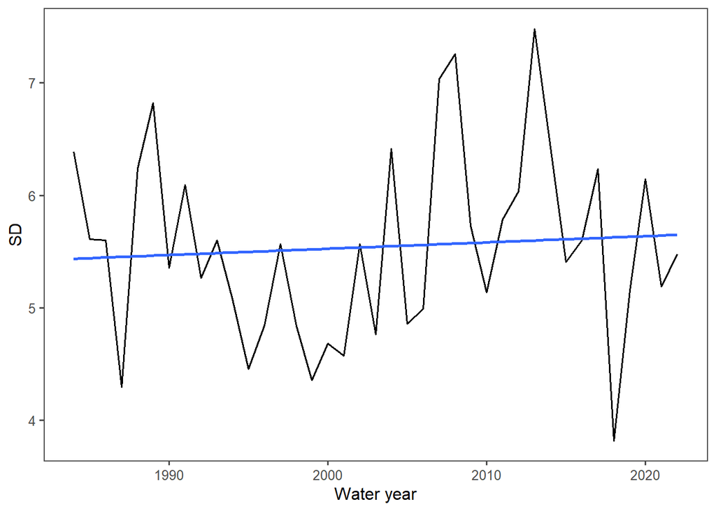

```r
ggplot(CO2184_standard_dev_all_winter, aes(x = waterYear, y = sd_2))+#, color = waterYear)) +
  geom_line(size= 0.7) +
  #geom_line(aes) +
  theme_few() +
  geom_smooth(method = "lm", se=FALSE) +
  ylab('SD') +
  xlab('Water year')
```

**CO2184 Nov-Mar standard deviation for water years 1984-2022**

Mann-Kendall & Sen’s Slope

Winter standard deviations.

```r
CO2184_sd_mk_winter <- mk.test(CO2184_standard_dev_all_winter$sd_2)
print(CO2184_sd_mk_winter)
```

```
##
##  Mann-Kendall trend test
##
## data:  CO2184_standard_dev_all_winter$sd_2
## z = 0.41129, n = 39, p-value = 0.6809
## alternative hypothesis: true S is not equal to 0
## sample estimates:
##            S         varS          tau
## 3.500000e+01 6.833667e+03 4.723347e-02
```

```r
CO2184_sd_sens_winter <- sens.slope(CO2184_standard_dev_all_winter$sd_2)
print(CO2184_sd_sens_winter)
```

```
##
##  Sen's slope
##
## data:  CO2184_standard_dev_all_winter$sd_2
## z = 0.41129, n = 39, p-value = 0.6809
## alternative hypothesis: true z is not equal to 0
## 95 percent confidence interval:
##  -0.02091837  0.03094743
## sample estimates:
## Sen's slope
## 0.005319822
```